# Lab 4

## RASGRF2 - Ras protein specific guanine nucleotide releasing factor 2

RAS GTPases cycle between an inactive GDP-bound state and an active GTP-bound state. Broad expression in brain and ovary etc. Diseases associated with RASGRF2 include Autism Spectrum Disorder(same as GPR37).

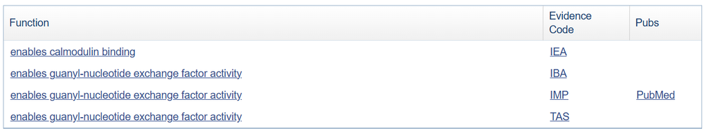

Gene Ontology functions

## Summary of similarities

Some common GO terms:

- Developmental Processes: Homeobox genes like HOXB7, HOXA5, and HOXB6 share roles in embryonic development and tissue differentiation.
- Signal Transduction: Genes such as GPR37, GABBR2 are integral to G-protein coupled receptor signaling.
- Metabolic and Biosynthetic Functions: ALDH1A2 and CYP27C1 are critical for vitamin A metabolism and other biochemical pathways.
- Immune Responses: IL1RL1 and SOCS2 are linked to cytokine signaling and inflammation regulation.

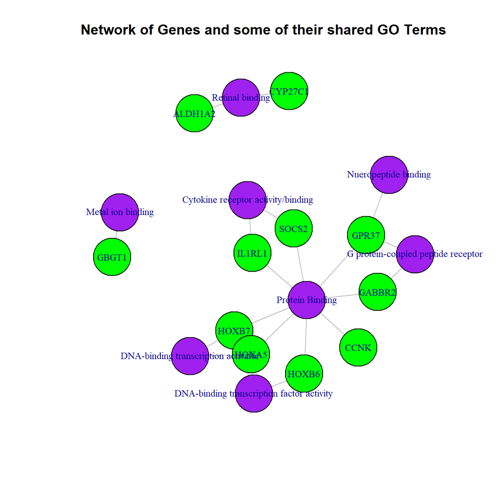

```r
# Load necessary libraries
library(igraph)

# List with some Go terms (not all)
go_terms <- list(
  "DNA-binding transcription activator" = c("HOXB7","HOXA5"),
  "DNA-binding transcription factor activity" = c("HOXB7","HOXA5","HOXB6"),
  "Protein Binding" = c("HOXB7","GPR37","IL1RL1","HOXA5","HOXB6","GABBR2","SOCS2","CCNK"),
  "G protein-coupled peptide receptor" = c('GPR37','GABBR2'),
  "Nueropeptide binding" = c("GPR37"),
  "Retinal binding" = c("ALDH1A2","CYP27C1"),
  "Cytokine receptor activity/binding" = c("IL1RL1","SOCS2"),
  "Metal ion binding"=c('GBGT1')
)

# Convert the list to a data frame
go_terms_df <- do.call(rbind, lapply(names(go_terms), function(term) {
  data.frame(
    GO_Term = term,
    Gene = go_terms[[term]]
  )
}))

# Create the graph
graph <- graph_from_data_frame(go_terms_df, directed = FALSE)

# Set node types (GO Terms vs Genes) on the Vertices
V(graph)$type <- ifelse(V(graph)$name %in% names(go_terms), "GO Term", "Gene")

# Set colors for nodes
V(graph)$color <- ifelse(V(graph)$type == "GO Term", "purple", "green")

plot(
  graph,
  vertex.color = V(graph)$color,
  vertex.label.cex = 0.8,
  vertex.size = 25,
  edge.color = "gray",
  main = "Network of Genes and some of their shared GO Terms"
)
```